# Tugas pertemuan 4 Praktikum Metode Peramalan Deret Waktu

# Proses MA(2)

Instruksi tugas:

- Melalui program R: Bangkitkan model MA(2) dengan 𝜃1 = 0.4 dan 𝜃2 = 0.6 sebanyak 300 data (Manual dan dengan arima.sim)
- Buat plot time series, plot ACF, plot PACF dan plot EACF. Idenifikasi apakah data tersebut stasioner
- Buat scatterplot antara 𝑌𝑡 dengan 𝑌𝑡−1, 𝑌𝑡 dengan 𝑌𝑡−2 serta 𝑌𝑡 dengan 𝑌𝑡−3
- Hitung autokorelasi masing masing baik dari data bangkitan maupun secara teoritis

## Melalui program R: Bangkitkan model MA(2) dengan 𝜃1 = 0.4 dan 𝜃2 = 0.6 sebanyak 300 data (Manual dan dengan arima.sim)

### Manual

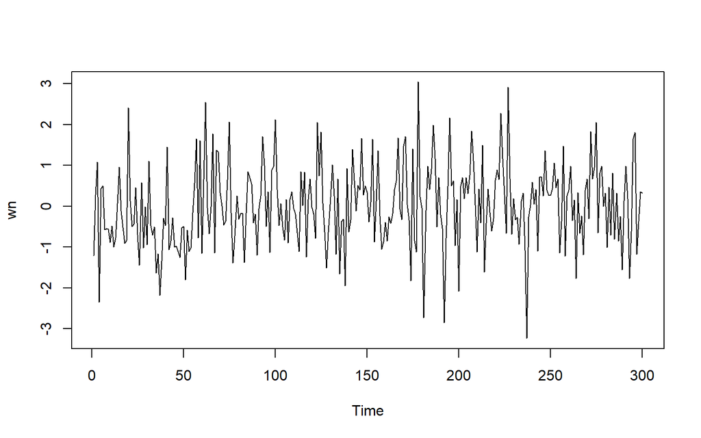

```r
set.seed(1234)
wn <- rnorm(300)
ts.plot(wn)
```

```r
ma <- c(wn[1], wn[2])

for(i in 3:300){
   ma[i] <- wn[i] + 0.4 * wn[i - 1] + 0.6 * wn[i - 2]
}

ma
```

```
##   [1] -1.207065749  0.277429242  0.471173424 -1.745463687  0.141510314
##   [6] -0.729712854 -0.114842790 -0.472894305 -1.127948717 -1.443797742
##  [11] -1.171879031 -1.723286222 -1.461924092 -0.845074607  0.519525249
##  [16]  0.312187420  0.020572732 -1.181770516 -1.508255550  1.534249256
##  [21]  0.598119283  1.012450498 -0.556369299 -0.011041246 -0.774213194
##  [26] -1.449939345 -0.420758391 -1.662676381 -0.079747157 -1.556197355
##  [31]  0.718835126 -0.596243221 -0.238298741 -1.070389923 -2.255260716
##  [36] -2.120011486 -3.624543435 -2.913580609 -2.138714925 -1.388210999
##  [41]  1.086560934 -0.768382742 -0.413123964 -1.263954490 -1.619808057
##  [46] -1.534624150 -2.091327966 -2.276021753 -1.689013389 -1.457572736
##  [51] -2.319068111 -1.602598402 -2.425338748 -1.807763414 -1.233628102
##  [56] -0.110845196  1.775654086  0.223607057  2.285258743 -0.979456751
##  [61]  1.157010823  2.116941328  1.378789117  0.845856907 -0.296314421
##  [66]  1.372262398 -0.432336811  1.978634754  1.193531021  1.688995021
##  [71]  0.939220832 -0.250827924 -0.544575725  0.228395751  2.109671129
```

[output cut: 45 more lines]

### arima.sim

```r
ma2 <- arima.sim(list(order=c(0,0,2), ma = c(0.4, 0.6)), n=300)
ma2
```

```
## Time Series:
## Start = 1
## End = 300
## Frequency = 1
##   [1] -0.908714261  0.366069559  0.319892749 -0.033692645 -0.749809541
##   [6]  1.023224875 -0.103827746  1.553027734  1.508813504  1.490258435
##  [11]  0.638775303  0.057508568 -0.761313741  1.006804154  0.046165301
##  [16]  2.226792228 -0.031351321  0.058227766 -0.452682262 -0.306828839
##  [21] -0.408896770 -1.768664231 -0.905163217 -1.653388217  0.814020129
##  [26] -0.949587092  1.394975120 -0.770061199  0.708742509  0.626264945
##  [31]  0.016220780  0.886163244 -0.177443664 -0.837739266 -0.776948985
##  [36]  0.830630275  0.271737011  0.068438994 -0.509614613 -0.182137038
##  [41]  1.054967504  1.724174690  1.131301118  1.891160132 -0.238116411
##  [46] -1.951472236 -1.868044756 -2.111236903 -2.805388403 -0.673455997
##  [51] -1.948408128 -0.202080988 -2.147789666 -0.222949385  1.157974906
```

[output cut: 49 more lines]

## Buat plot time series, plot ACF, plot PACF dan plot EACF. Idenifikasi apakah data tersebut stasioner

### Plot time series

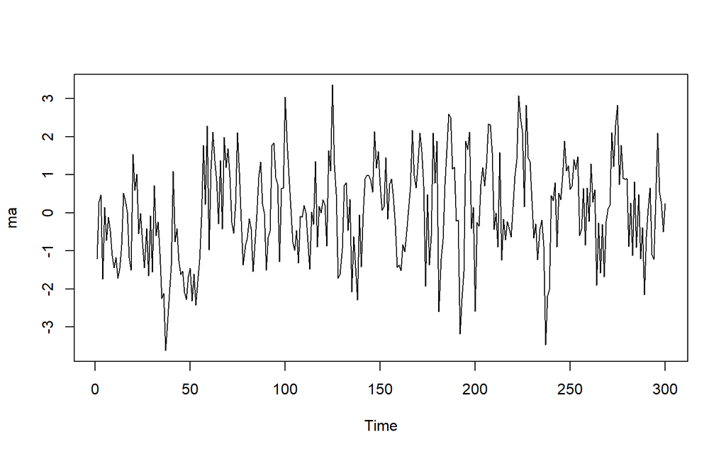

```r
ts.plot(ma)
```

Berdasarkan plot time series, terlihat bahwa data MA(2) yang dibangkitkan stasioner dalam rataan

### Plot ACF

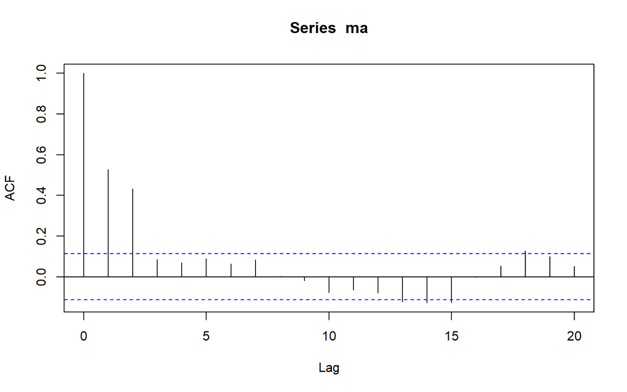

```r
acf(ma,lag.max = 20)
```

Berdasarkan plot ACF MA(2) tersebut, terlihat bahwa plot ACF cuts off di lag kedua. Setelah lag ke-2 sebagian besar nilai acf berada di dalam interval kepercayaan. artinya terlihat bahwa autokorelasi pada lag 1 dan 2 signifikan karena melewati batas interval kepercayaan.

### Plot PACF

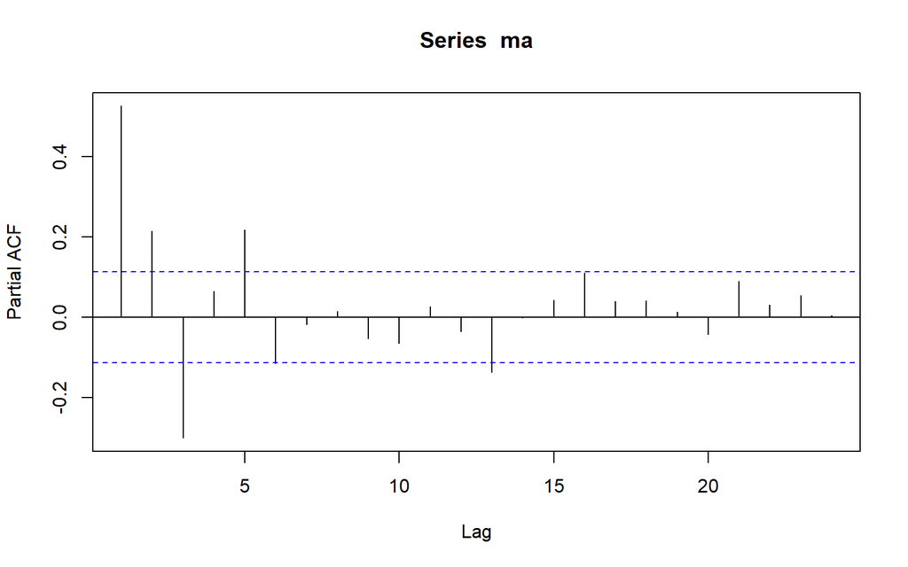

```r
pacf(ma)
```

Berdasarkan plot PACF MA(2), terlihat bahwa plot PACF cenderung tails off, yaitu nilaii autokorelasi parsial mengecil secara bertahap setelah beberapa lag.

### plot EACF

```r
TSA::eacf(ma)
```

```
## AR/MA
##   0 1 2 3 4 5 6 7 8 9 10 11 12 13
## 0 x x o o o o o o o o o  o  x  x
## 1 x x x o o o o o o o o  o  o  o
## 2 x x x x o o o o o o o  o  o  o
## 3 x x x x x o o o o o o  o  o  o
## 4 x x x x x o o o o o o  o  o  o
## 5 x x x x x o x o o o o  o  o  o
## 6 x x x o x o o x o o o  o  o  o
## 7 x o x o x o o x o o o  o  o  o
```

Berdasarkan pola segitiga nol pada plot EACF, terlihat bahwa segitiga nol berada pada ordo AR(0) dan ordo MA(2)

## Buat scatterplot antara 𝑌𝑡 dengan 𝑌𝑡−1, 𝑌𝑡 dengan 𝑌𝑡−2 serta 𝑌𝑡 dengan 𝑌𝑡−3

### 𝑌𝑡 dengan 𝑌𝑡−1

```r
#Yt
yt_ma <- ma[-1]
yt_ma
```

```
##   [1]  0.277429242  0.471173424 -1.745463687  0.141510314 -0.729712854
##   [6] -0.114842790 -0.472894305 -1.127948717 -1.443797742 -1.171879031
##  [11] -1.723286222 -1.461924092 -0.845074607  0.519525249  0.312187420
##  [16]  0.020572732 -1.181770516 -1.508255550  1.534249256  0.598119283
##  [21]  1.012450498 -0.556369299 -0.011041246 -0.774213194 -1.449939345
##  [26] -0.420758391 -1.662676381 -0.079747157 -1.556197355  0.718835126
##  [31] -0.596243221 -0.238298741 -1.070389923 -2.255260716 -2.120011486
##  [36] -3.624543435 -2.913580609 -2.138714925 -1.388210999  1.086560934
##  [41] -0.768382742 -0.413123964 -1.263954490 -1.619808057 -1.534624150
##  [46] -2.091327966 -2.276021753 -1.689013389 -1.457572736 -2.319068111
##  [51] -1.602598402 -2.425338748 -1.807763414 -1.233628102 -0.110845196
##  [56]  1.775654086  0.223607057  2.285258743 -0.979456751  1.157010823
##  [61]  2.116941328  1.378789117  0.845856907 -0.296314421  1.372262398
##  [66] -0.432336811  1.978634754  1.193531021  1.688995021  0.939220832
##  [71] -0.250827924 -0.544575725  0.228395751  2.109671129  1.063681873
```

[output cut: 45 more lines]

```r
#Yt-1
yt_1_ma <- ma[-300]
yt_1_ma
```

```
##   [1] -1.207065749  0.277429242  0.471173424 -1.745463687  0.141510314
##   [6] -0.729712854 -0.114842790 -0.472894305 -1.127948717 -1.443797742
##  [11] -1.171879031 -1.723286222 -1.461924092 -0.845074607  0.519525249
##  [16]  0.312187420  0.020572732 -1.181770516 -1.508255550  1.534249256
##  [21]  0.598119283  1.012450498 -0.556369299 -0.011041246 -0.774213194
##  [26] -1.449939345 -0.420758391 -1.662676381 -0.079747157 -1.556197355
##  [31]  0.718835126 -0.596243221 -0.238298741 -1.070389923 -2.255260716
##  [36] -2.120011486 -3.624543435 -2.913580609 -2.138714925 -1.388210999
##  [41]  1.086560934 -0.768382742 -0.413123964 -1.263954490 -1.619808057
##  [46] -1.534624150 -2.091327966 -2.276021753 -1.689013389 -1.457572736
##  [51] -2.319068111 -1.602598402 -2.425338748 -1.807763414 -1.233628102
##  [56] -0.110845196  1.775654086  0.223607057  2.285258743 -0.979456751
##  [61]  1.157010823  2.116941328  1.378789117  0.845856907 -0.296314421
##  [66]  1.372262398 -0.432336811  1.978634754  1.193531021  1.688995021
##  [71]  0.939220832 -0.250827924 -0.544575725  0.228395751  2.109671129
```

[output cut: 45 more lines]

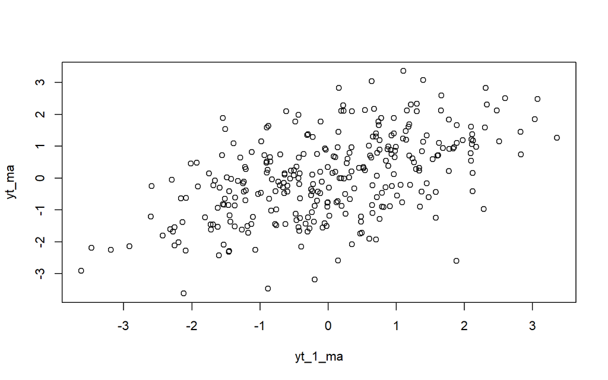

```r
plot(y=yt_ma,x=yt_1_ma)
```

### 𝑌𝑡 dengan 𝑌𝑡−2

```r
#Yt
yt_ma2 <- ma[-c(1,2)]
yt_ma2
```

```
##   [1]  0.471173424 -1.745463687  0.141510314 -0.729712854 -0.114842790
##   [6] -0.472894305 -1.127948717 -1.443797742 -1.171879031 -1.723286222
##  [11] -1.461924092 -0.845074607  0.519525249  0.312187420  0.020572732
##  [16] -1.181770516 -1.508255550  1.534249256  0.598119283  1.012450498
##  [21] -0.556369299 -0.011041246 -0.774213194 -1.449939345 -0.420758391
##  [26] -1.662676381 -0.079747157 -1.556197355  0.718835126 -0.596243221
##  [31] -0.238298741 -1.070389923 -2.255260716 -2.120011486 -3.624543435
##  [36] -2.913580609 -2.138714925 -1.388210999  1.086560934 -0.768382742
##  [41] -0.413123964 -1.263954490 -1.619808057 -1.534624150 -2.091327966
##  [46] -2.276021753 -1.689013389 -1.457572736 -2.319068111 -1.602598402
##  [51] -2.425338748 -1.807763414 -1.233628102 -0.110845196  1.775654086
##  [56]  0.223607057  2.285258743 -0.979456751  1.157010823  2.116941328
##  [61]  1.378789117  0.845856907 -0.296314421  1.372262398 -0.432336811
##  [66]  1.978634754  1.193531021  1.688995021  0.939220832 -0.250827924
##  [71] -0.544575725  0.228395751  2.109671129  1.063681873 -0.209897795
```

[output cut: 45 more lines]

```r
#Yt-2
yt_2_ma <- ma[-c(299,300)]
yt_2_ma
```

```
##   [1] -1.207065749  0.277429242  0.471173424 -1.745463687  0.141510314
##   [6] -0.729712854 -0.114842790 -0.472894305 -1.127948717 -1.443797742
##  [11] -1.171879031 -1.723286222 -1.461924092 -0.845074607  0.519525249
##  [16]  0.312187420  0.020572732 -1.181770516 -1.508255550  1.534249256
##  [21]  0.598119283  1.012450498 -0.556369299 -0.011041246 -0.774213194
##  [26] -1.449939345 -0.420758391 -1.662676381 -0.079747157 -1.556197355
##  [31]  0.718835126 -0.596243221 -0.238298741 -1.070389923 -2.255260716
##  [36] -2.120011486 -3.624543435 -2.913580609 -2.138714925 -1.388210999
##  [41]  1.086560934 -0.768382742 -0.413123964 -1.263954490 -1.619808057
##  [46] -1.534624150 -2.091327966 -2.276021753 -1.689013389 -1.457572736
##  [51] -2.319068111 -1.602598402 -2.425338748 -1.807763414 -1.233628102
##  [56] -0.110845196  1.775654086  0.223607057  2.285258743 -0.979456751
##  [61]  1.157010823  2.116941328  1.378789117  0.845856907 -0.296314421
##  [66]  1.372262398 -0.432336811  1.978634754  1.193531021  1.688995021
##  [71]  0.939220832 -0.250827924 -0.544575725  0.228395751  2.109671129
```

[output cut: 45 more lines]

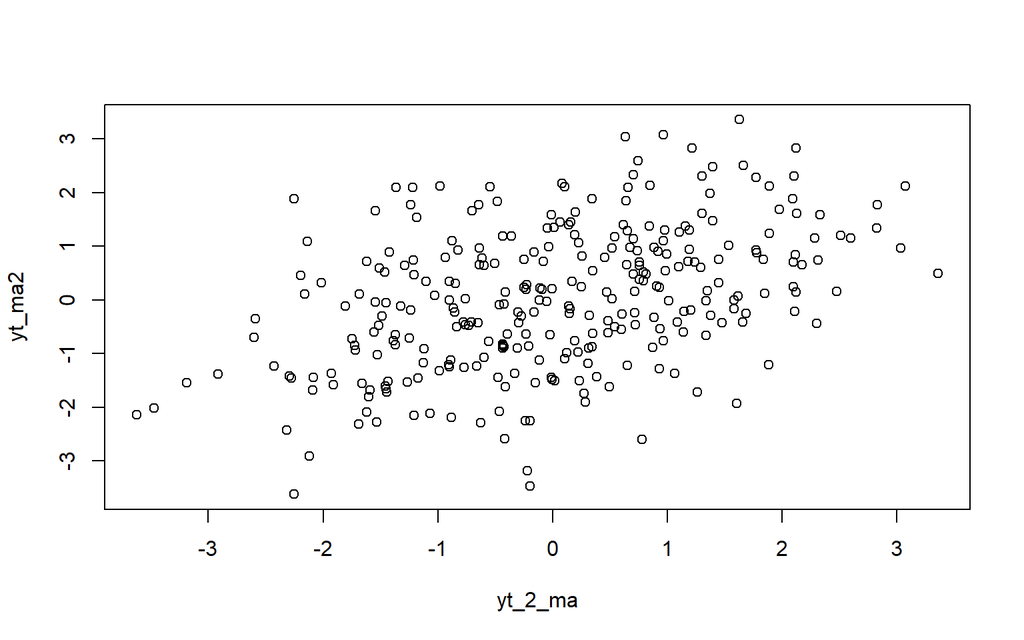

```r
plot(y=yt_ma2,x=yt_2_ma)
```

### 𝑌𝑡 dengan 𝑌𝑡−3

```r
# Yt
yt_ma3 <- ma[-c(1,2,3)]
yt_ma3
```

```
##   [1] -1.745463687  0.141510314 -0.729712854 -0.114842790 -0.472894305
##   [6] -1.127948717 -1.443797742 -1.171879031 -1.723286222 -1.461924092
##  [11] -0.845074607  0.519525249  0.312187420  0.020572732 -1.181770516
##  [16] -1.508255550  1.534249256  0.598119283  1.012450498 -0.556369299
##  [21] -0.011041246 -0.774213194 -1.449939345 -0.420758391 -1.662676381
##  [26] -0.079747157 -1.556197355  0.718835126 -0.596243221 -0.238298741
##  [31] -1.070389923 -2.255260716 -2.120011486 -3.624543435 -2.913580609
##  [36] -2.138714925 -1.388210999  1.086560934 -0.768382742 -0.413123964
##  [41] -1.263954490 -1.619808057 -1.534624150 -2.091327966 -2.276021753
##  [46] -1.689013389 -1.457572736 -2.319068111 -1.602598402 -2.425338748
##  [51] -1.807763414 -1.233628102 -0.110845196  1.775654086  0.223607057
##  [56]  2.285258743 -0.979456751  1.157010823  2.116941328  1.378789117
##  [61]  0.845856907 -0.296314421  1.372262398 -0.432336811  1.978634754
##  [66]  1.193531021  1.688995021  0.939220832 -0.250827924 -0.544575725
##  [71]  0.228395751  2.109671129  1.063681873 -0.209897795 -1.371901203
```

[output cut: 45 more lines]

```r
# Yt-3
yt_3_ma <- ma[-c(298,299,300)]
yt_3_ma
```

```
##   [1] -1.207065749  0.277429242  0.471173424 -1.745463687  0.141510314
##   [6] -0.729712854 -0.114842790 -0.472894305 -1.127948717 -1.443797742
##  [11] -1.171879031 -1.723286222 -1.461924092 -0.845074607  0.519525249
##  [16]  0.312187420  0.020572732 -1.181770516 -1.508255550  1.534249256
##  [21]  0.598119283  1.012450498 -0.556369299 -0.011041246 -0.774213194
##  [26] -1.449939345 -0.420758391 -1.662676381 -0.079747157 -1.556197355
##  [31]  0.718835126 -0.596243221 -0.238298741 -1.070389923 -2.255260716
##  [36] -2.120011486 -3.624543435 -2.913580609 -2.138714925 -1.388210999
##  [41]  1.086560934 -0.768382742 -0.413123964 -1.263954490 -1.619808057
##  [46] -1.534624150 -2.091327966 -2.276021753 -1.689013389 -1.457572736
##  [51] -2.319068111 -1.602598402 -2.425338748 -1.807763414 -1.233628102
##  [56] -0.110845196  1.775654086  0.223607057  2.285258743 -0.979456751
##  [61]  1.157010823  2.116941328  1.378789117  0.845856907 -0.296314421
##  [66]  1.372262398 -0.432336811  1.978634754  1.193531021  1.688995021
##  [71]  0.939220832 -0.250827924 -0.544575725  0.228395751  2.109671129
```

[output cut: 45 more lines]

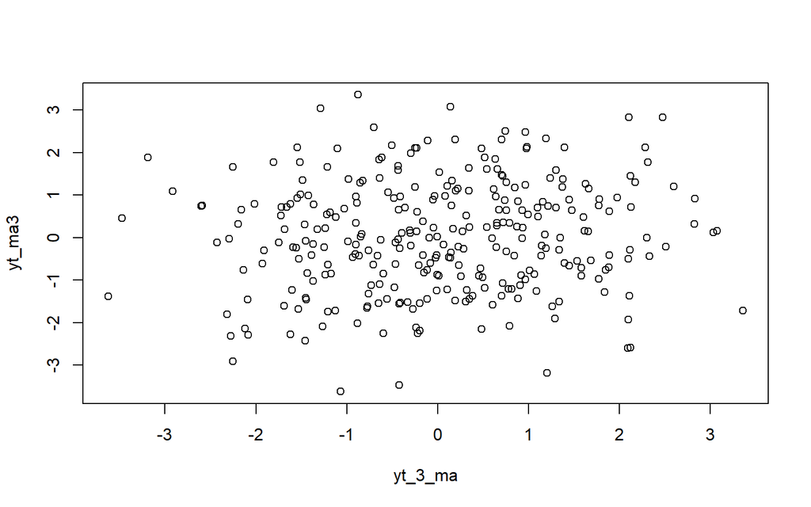

```r
# Scatterplot
plot(y=yt_ma3,x=yt_3_ma)
```

## Hitung autokorelasi masing masing baik dari data bangkitan maupun secara teoritis

### 𝑌𝑡 dengan 𝑌𝑡−1

```r
cor(yt_ma,yt_1_ma)
```

```
## [1] 0.5274606
```

$$\rho_1 =
\frac{-\theta_1+\theta_1\theta_2}
{1+\theta_1^2+\theta_2^2}
=
\frac{-(-0.4)+(-0.4)(-0.6)}
{1+(-0.4)^2+(-0.6)^2}
=
\frac{0.4+0.24}{1+0.16+0.36}
=
\frac{0.64}{1.52}
=
0.4211$$

### 𝑌𝑡 dengan 𝑌𝑡−2

```r
cor(yt_ma2,yt_2_ma)
```

```
## [1] 0.4339293
```

$$\rho_2 =
\frac{-\theta_2}
{1+\theta_1^2+\theta_2^2}
=
\frac{-(-0.6)}
{1+(-0.4)^2+(-0.6)^2}
=
\frac{0.6}{1+0.16+0.36}
=
\frac{0.6}{1.52}
=
0.3947$$

### 𝑡 dengan 𝑌𝑡−3

```r
cor(yt_ma3,yt_3_ma)
```

```
## [1] 0.08555282
```

Secara teoritis,

$$\rho_3 = 0$$

karena $k>q$, dengan $q=2$, sehingga

$$\rho_k=0,\quad k>2$$

# Proses AR(2)

Instruksi tugas: Melalui program R: - Bangkitkan model AR(2) dengan 𝜙1 = 0.5 dan 𝜙2 = 0.2 sebanyak 300 data (Manual dan dengan arima.sim) - Buat plot time series, plot ACF, plot PACF dan plot EACF. Idenifikasi apakah data tersebut stasioner - Buat scatterplot antara 𝑌𝑡 dengan 𝑌𝑡−1, 𝑌𝑡 dengan 𝑌𝑡−2 serta 𝑌𝑡dengan 𝑌𝑡−3 - Hitung autokorelasi masing masing baik dari data bangkitan maupun secara teoriti

## Bangkitkan model AR(2) dengan 𝜙1 = 0.5 dan 𝜙2 = 0.2 sebanyak 300 data (Manual dan dengan arima.sim)

### manual

```r
set.seed(1234)
n<-length(wn)
n
```

```
## [1] 300
```

```r
ar <- c(1:n)
for (i in 3:n) {ar[i]<-wn[i]+0.5*ar[i-1] + 0.2*ar[i-2]}
ar
```

```
##   [1]  1.000000000  2.000000000  2.284441177 -0.803477114  0.484274367
##   [6]  0.587497653 -0.184136260 -0.521200455 -0.861879479 -1.425217660
##  [11] -1.362177425 -1.964518689 -2.030948724 -1.343919283 -0.118655327
##  [16] -0.438397015 -0.753939079 -1.375844359 -1.675881675  1.302725469
##  [21]  0.450274620 -0.005003493 -0.352994695  0.282091395 -0.623273488
##  [26] -1.703423376 -0.401610665 -1.565145730 -0.878033298 -1.687994396
##  [31]  0.082693688 -0.771845114 -1.078823857 -1.195039012 -2.442377746
##  [36] -2.627815938 -3.982423167 -3.857767963 -3.019662474 -2.747282370
##  [41] -0.528077414 -1.882137905 -1.902049069 -1.608075117 -2.178787449
##  [46] -2.379523066 -2.732837215 -3.094309106 -2.617550115 -2.424486836
##  [51] -3.541784698 -2.837865641 -3.236179384 -3.200624830 -2.409857815
##  [56] -1.281998055  0.524846882 -0.767329594  1.327214208 -0.647667362
##  [61]  0.598197625  2.718556411  1.444157341  0.596156373  0.579304899
##  [66]  2.185968172  0.070237329  1.840139478  2.263681996  1.836341691
##  [71]  1.377800083  0.600699641  0.209385904  0.873119448  2.548707766
```

[output cut: 45 more lines]

### arima.sim

```r
ar2 <- arima.sim(list(order=c(2,0,0), ar=c(0.5, 0.2)), n=300)
ar2
```

```
## Time Series:
## Start = 1
## End = 300
## Frequency = 1
##   [1] -1.7066325607 -0.4040571790 -1.5670108246 -0.8794551485 -1.6890783403
##   [6]  0.0818673463 -0.7724750738 -1.0793041051 -1.1954051279 -2.4426568541
##  [11] -2.6280287147 -3.9825853771 -3.8578916236 -3.0197567460 -2.7473542381
##  [16] -0.5281322030 -1.8821796728 -1.9020809107 -1.6080993919 -2.1788059544
##  [21] -2.3795371734 -2.7328479702 -3.0943173054 -2.6175563658 -2.4244916012
##  [26] -3.5417883306 -2.8378684102 -3.2361814957 -3.2006264394 -2.4098590424
##  [31] -1.2819989901  0.5248461693 -0.7673301373  1.3272137941 -0.6476676781
##  [36]  0.5981973841  2.7185562271  1.4441572006  0.5961562661  0.5793048174
##  [41]  2.1859681101  0.0702372818  1.8401394423  2.2636819683  1.8363416698
##  [46]  1.3778000670  0.6006996293  0.2093858952  0.8731194410  2.5487077608
##  [51]  1.2955793561 -0.2331697165 -0.5810507641 -0.0788975632 -0.4727180494
```

[output cut: 49 more lines]

## Buat plot time series, plot ACF, plot PACF dan plot EACF. Idenifikasi apakah data tersebut stasioner

### plot time series

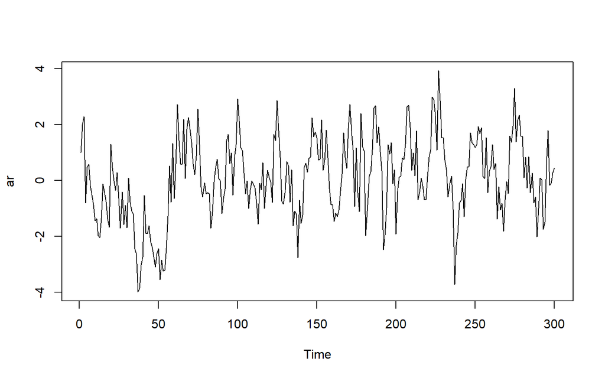

```r
ts.plot(ar)
```

Berdasarkan plot time series tersebut terlihat bahwa data cenderung stasioner pada rataan

### plot ACF

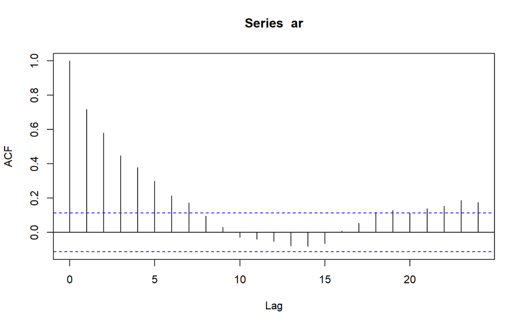

```r
acf(ar)
```

Plot ACF menunjukkan pola tails off, yaitu nilai autokorelasi secara bertahap menurun menuju nol seiring bertambahnya lag. Pola ini sesuai dengan karakteristik model AR(2), dimana ACF tidak terputus (cuts off ) secara langsung pada lag tertentu. dan sedikit cenderung membentuk pola grafik sinus

### plot PACF

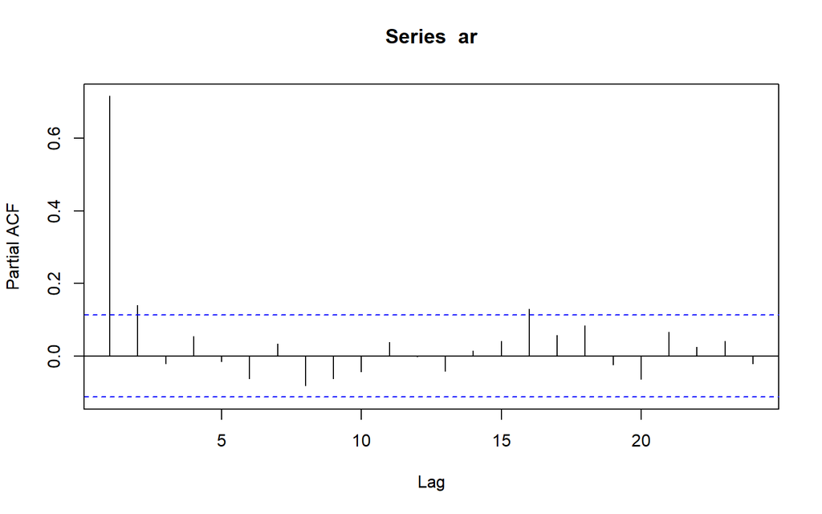

```r
pacf(ar)
```

Berdasarkan plot PACF tersebut, terlihat bahwa plot PACF cuts off pada lag kedua, sejalan dengan teori yang ada.

### plot EACF

```r
TSA::eacf(ar)
```

```
## AR/MA
##   0 1 2 3 4 5 6 7 8 9 10 11 12 13
## 0 x x x x x x x o o o o  o  o  o
## 1 x o o o o o o o o o o  o  o  o
## 2 x o o o o o o o o o o  o  o  o
## 3 x x o o o o o o o o o  o  o  o
## 4 x x o o o o o o o o o  o  o  o
## 5 x x x x o o x o o o o  o  o  o
## 6 x x x x o o o o o o o  o  o  o
## 7 x x x o x x o o o o o  o  o  o
```

Berdasarkan pola segitiga nol pada plot EACF, terlihat bahwa segitiga nol berada pada ordo AR(1) dan ordo MA(1)

## Buat scatterplot antara 𝑌𝑡 dengan 𝑌𝑡−1, 𝑌𝑡 dengan 𝑌𝑡−2 serta 𝑌𝑡dengan 𝑌𝑡−3

### 𝑌𝑡 dengan 𝑌𝑡−1

```r
#Yt
yt_ar <- ar[-1]
yt_ar
```

```
##   [1]  2.000000000  2.284441177 -0.803477114  0.484274367  0.587497653
##   [6] -0.184136260 -0.521200455 -0.861879479 -1.425217660 -1.362177425
##  [11] -1.964518689 -2.030948724 -1.343919283 -0.118655327 -0.438397015
##  [16] -0.753939079 -1.375844359 -1.675881675  1.302725469  0.450274620
##  [21] -0.005003493 -0.352994695  0.282091395 -0.623273488 -1.703423376
##  [26] -0.401610665 -1.565145730 -0.878033298 -1.687994396  0.082693688
##  [31] -0.771845114 -1.078823857 -1.195039012 -2.442377746 -2.627815938
##  [36] -3.982423167 -3.857767963 -3.019662474 -2.747282370 -0.528077414
##  [41] -1.882137905 -1.902049069 -1.608075117 -2.178787449 -2.379523066
##  [46] -2.732837215 -3.094309106 -2.617550115 -2.424486836 -3.541784698
##  [51] -2.837865641 -3.236179384 -3.200624830 -2.409857815 -1.281998055
##  [56]  0.524846882 -0.767329594  1.327214208 -0.647667362  0.598197625
##  [61]  2.718556411  1.444157341  0.596156373  0.579304899  2.185968172
##  [66]  0.070237329  1.840139478  2.263681996  1.836341691  1.377800083
##  [71]  0.600699641  0.209385904  0.873119448  2.548707766  1.295579360
```

[output cut: 45 more lines]

```r
#Yt-1
yt_1_ar <- ar[-300]
yt_1_ar
```

```
##   [1]  1.000000000  2.000000000  2.284441177 -0.803477114  0.484274367
##   [6]  0.587497653 -0.184136260 -0.521200455 -0.861879479 -1.425217660
##  [11] -1.362177425 -1.964518689 -2.030948724 -1.343919283 -0.118655327
##  [16] -0.438397015 -0.753939079 -1.375844359 -1.675881675  1.302725469
##  [21]  0.450274620 -0.005003493 -0.352994695  0.282091395 -0.623273488
##  [26] -1.703423376 -0.401610665 -1.565145730 -0.878033298 -1.687994396
##  [31]  0.082693688 -0.771845114 -1.078823857 -1.195039012 -2.442377746
##  [36] -2.627815938 -3.982423167 -3.857767963 -3.019662474 -2.747282370
##  [41] -0.528077414 -1.882137905 -1.902049069 -1.608075117 -2.178787449
##  [46] -2.379523066 -2.732837215 -3.094309106 -2.617550115 -2.424486836
##  [51] -3.541784698 -2.837865641 -3.236179384 -3.200624830 -2.409857815
##  [56] -1.281998055  0.524846882 -0.767329594  1.327214208 -0.647667362
##  [61]  0.598197625  2.718556411  1.444157341  0.596156373  0.579304899
##  [66]  2.185968172  0.070237329  1.840139478  2.263681996  1.836341691
##  [71]  1.377800083  0.600699641  0.209385904  0.873119448  2.548707766
```

[output cut: 45 more lines]

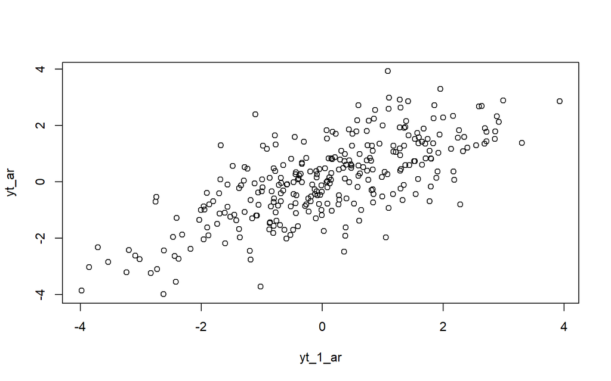

```r
plot(y=yt_ar,x=yt_1_ar)
```

### 𝑌𝑡 dengan 𝑌𝑡−2

```r
#Yt
yt_ar2 <- ar[-c(1,2)]
yt_ar2
```

```
##   [1]  2.284441177 -0.803477114  0.484274367  0.587497653 -0.184136260
##   [6] -0.521200455 -0.861879479 -1.425217660 -1.362177425 -1.964518689
##  [11] -2.030948724 -1.343919283 -0.118655327 -0.438397015 -0.753939079
##  [16] -1.375844359 -1.675881675  1.302725469  0.450274620 -0.005003493
##  [21] -0.352994695  0.282091395 -0.623273488 -1.703423376 -0.401610665
##  [26] -1.565145730 -0.878033298 -1.687994396  0.082693688 -0.771845114
##  [31] -1.078823857 -1.195039012 -2.442377746 -2.627815938 -3.982423167
##  [36] -3.857767963 -3.019662474 -2.747282370 -0.528077414 -1.882137905
##  [41] -1.902049069 -1.608075117 -2.178787449 -2.379523066 -2.732837215
##  [46] -3.094309106 -2.617550115 -2.424486836 -3.541784698 -2.837865641
##  [51] -3.236179384 -3.200624830 -2.409857815 -1.281998055  0.524846882
##  [56] -0.767329594  1.327214208 -0.647667362  0.598197625  2.718556411
##  [61]  1.444157341  0.596156373  0.579304899  2.185968172  0.070237329
##  [66]  1.840139478  2.263681996  1.836341691  1.377800083  0.600699641
##  [71]  0.209385904  0.873119448  2.548707766  1.295579360 -0.233169713
```

[output cut: 45 more lines]

```r
#Yt-2
yt_2_ar <- ar[-c(299,300)]
yt_2_ar
```

```
##   [1]  1.000000000  2.000000000  2.284441177 -0.803477114  0.484274367
##   [6]  0.587497653 -0.184136260 -0.521200455 -0.861879479 -1.425217660
##  [11] -1.362177425 -1.964518689 -2.030948724 -1.343919283 -0.118655327
##  [16] -0.438397015 -0.753939079 -1.375844359 -1.675881675  1.302725469
##  [21]  0.450274620 -0.005003493 -0.352994695  0.282091395 -0.623273488
##  [26] -1.703423376 -0.401610665 -1.565145730 -0.878033298 -1.687994396
##  [31]  0.082693688 -0.771845114 -1.078823857 -1.195039012 -2.442377746
##  [36] -2.627815938 -3.982423167 -3.857767963 -3.019662474 -2.747282370
##  [41] -0.528077414 -1.882137905 -1.902049069 -1.608075117 -2.178787449
##  [46] -2.379523066 -2.732837215 -3.094309106 -2.617550115 -2.424486836
##  [51] -3.541784698 -2.837865641 -3.236179384 -3.200624830 -2.409857815
##  [56] -1.281998055  0.524846882 -0.767329594  1.327214208 -0.647667362
##  [61]  0.598197625  2.718556411  1.444157341  0.596156373  0.579304899
##  [66]  2.185968172  0.070237329  1.840139478  2.263681996  1.836341691
##  [71]  1.377800083  0.600699641  0.209385904  0.873119448  2.548707766
```

[output cut: 45 more lines]

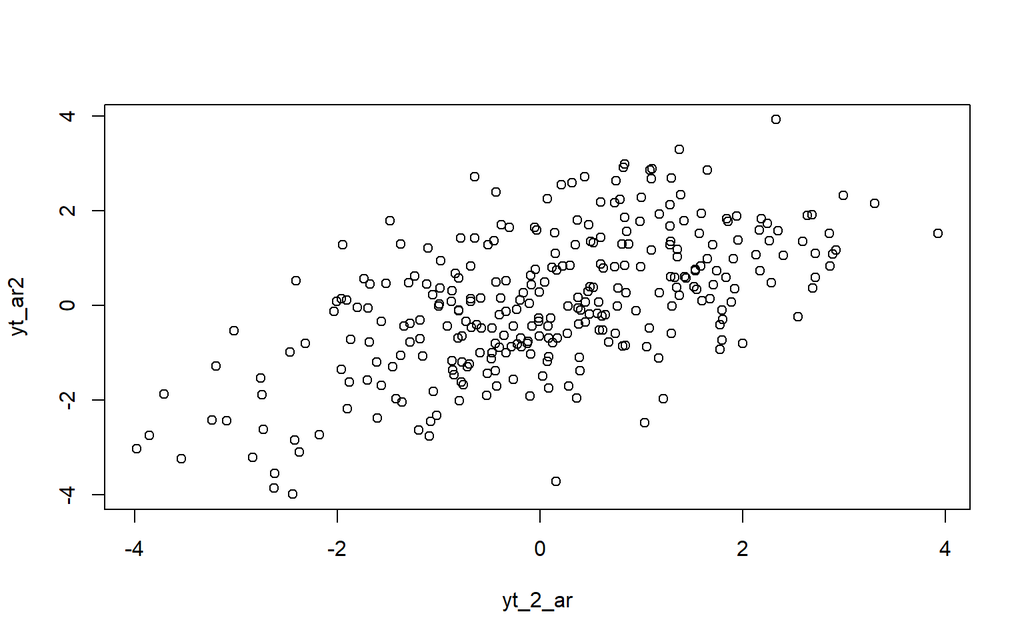

```r
plot(y=yt_ar2,x=yt_2_ar)
```

### 𝑌𝑡dengan 𝑌𝑡−3

```r
# Yt
yt_ar3 <- ar[-c(1,2,3)]
yt_ar3
```

```
##   [1] -0.803477114  0.484274367  0.587497653 -0.184136260 -0.521200455
##   [6] -0.861879479 -1.425217660 -1.362177425 -1.964518689 -2.030948724
##  [11] -1.343919283 -0.118655327 -0.438397015 -0.753939079 -1.375844359
##  [16] -1.675881675  1.302725469  0.450274620 -0.005003493 -0.352994695
##  [21]  0.282091395 -0.623273488 -1.703423376 -0.401610665 -1.565145730
##  [26] -0.878033298 -1.687994396  0.082693688 -0.771845114 -1.078823857
##  [31] -1.195039012 -2.442377746 -2.627815938 -3.982423167 -3.857767963
##  [36] -3.019662474 -2.747282370 -0.528077414 -1.882137905 -1.902049069
##  [41] -1.608075117 -2.178787449 -2.379523066 -2.732837215 -3.094309106
##  [46] -2.617550115 -2.424486836 -3.541784698 -2.837865641 -3.236179384
##  [51] -3.200624830 -2.409857815 -1.281998055  0.524846882 -0.767329594
##  [56]  1.327214208 -0.647667362  0.598197625  2.718556411  1.444157341
##  [61]  0.596156373  0.579304899  2.185968172  0.070237329  1.840139478
##  [66]  2.263681996  1.836341691  1.377800083  0.600699641  0.209385904
##  [71]  0.873119448  2.548707766  1.295579360 -0.233169713 -0.581050762
```

[output cut: 45 more lines]

```r
# Yt-3
yt_3_ar <- ar[-c(298,299,300)]
yt_3_ar
```

```
##   [1]  1.000000000  2.000000000  2.284441177 -0.803477114  0.484274367
##   [6]  0.587497653 -0.184136260 -0.521200455 -0.861879479 -1.425217660
##  [11] -1.362177425 -1.964518689 -2.030948724 -1.343919283 -0.118655327
##  [16] -0.438397015 -0.753939079 -1.375844359 -1.675881675  1.302725469
##  [21]  0.450274620 -0.005003493 -0.352994695  0.282091395 -0.623273488
##  [26] -1.703423376 -0.401610665 -1.565145730 -0.878033298 -1.687994396
##  [31]  0.082693688 -0.771845114 -1.078823857 -1.195039012 -2.442377746
##  [36] -2.627815938 -3.982423167 -3.857767963 -3.019662474 -2.747282370
##  [41] -0.528077414 -1.882137905 -1.902049069 -1.608075117 -2.178787449
##  [46] -2.379523066 -2.732837215 -3.094309106 -2.617550115 -2.424486836
##  [51] -3.541784698 -2.837865641 -3.236179384 -3.200624830 -2.409857815
##  [56] -1.281998055  0.524846882 -0.767329594  1.327214208 -0.647667362
##  [61]  0.598197625  2.718556411  1.444157341  0.596156373  0.579304899
##  [66]  2.185968172  0.070237329  1.840139478  2.263681996  1.836341691
##  [71]  1.377800083  0.600699641  0.209385904  0.873119448  2.548707766
```

[output cut: 45 more lines]

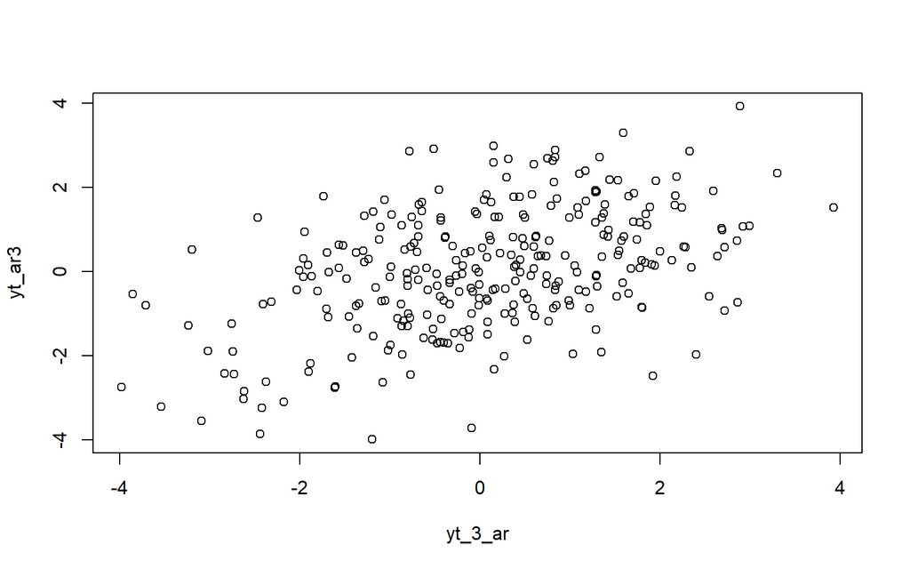

```r
plot(y=yt_ar3, x=yt_3_ar)
```

## Hitung autokorelasi masing masing baik dari data bangkitan maupun secara teoritiS

### 𝑌𝑡 dengan 𝑌𝑡−1

```r
cor(yt_ar,yt_1_ar)
```

```
## [1] 0.7173171
```

$$\begin{aligned}
\rho_1
&= \frac{\phi_1}{1-\phi_2}\\
&= \frac{0.5}{1-0.2}\\
&= \frac{0.5}{0.8}\\
&= 0.625.
\end{aligned}$$

### 𝑌𝑡 dengan 𝑌𝑡−2

```r
cor(yt_ar2, yt_2_ar)
```

```
## [1] 0.5836665
```

$$\begin{aligned}
\rho_2
&= \phi_1\rho_1 + \phi_2\rho_0\\
&= (0.5)(0.625) + (0.2)(1)\\
&= 0.3125 + 0.2\\
&= 0.5125.
\end{aligned}$$

### 𝑌𝑡dengan 𝑌𝑡−3

```r
cor(yt_ar3, yt_3_ar)
```

```
## [1] 0.4522274
```

$$\begin{aligned}
\rho_3
&= \phi_1\rho_2 + \phi_2\rho_1\\
&= (0.5)(0.5125) + (0.2)(0.625)\\
&= 0.25625 + 0.125\\
&= 0.38125.
\end{aligned}$$

# Proses ARMA(2,2)

Melalui program R: - Bangkitkan model ARMA(2,2) dengan 𝜃1 = 0.4, 𝜃2 = 0.6 ,𝜙1 = 0.5 dan 𝜙2 = 0.2 sebanyak 300 data (Manual dan arima.sim) - Buat plot time series, plot ACF, plot PACF dan plot EACF. Idenifikasi apakah data tersebut stasioner - Buat scatterplot antara 𝑌𝑡 dengan 𝑌𝑡−1, 𝑌𝑡 dengan 𝑌𝑡−2 serta 𝑌𝑡 dengan 𝑌𝑡−3 - Hitung autokorelasi masing masing baik dari data bangkitan maupun secara teoriti

## Bangkitkan model ARMA(2,2) dengan 𝜃1 = 0.4, 𝜃2 = 0.6 ,𝜙1 = 0.5 dan 𝜙2 = 0.2 sebanyak 300 data (Manual dan arima.sim)

### manual

```r
set.seed(1234)
n = length(wn)
n
```

```
## [1] 300
```

```r
phi1 = 0.5
phi2 = 0.2

theta1 = 0.4
theta2 = 0.6

y.arma=c(1:n)

for (i in 3:n){y.arma[i] = phi1*y.arma[i-1] + phi2*y.arma[i-2] + theta1*wn[i-1] + theta2*wn[i-2] + wn[i]}

y.arma
```

```
##   [1]  1.00000000  2.00000000  1.67117342 -0.50987697  0.22080651 -0.72128499
##   [7] -0.43132398 -0.83281330 -1.63062016 -2.42567048 -2.71083830 -3.56383947
##  [13] -3.78601149 -3.45084825 -1.96310117 -1.35953282 -1.05181391 -1.97958403
##  [19] -2.70841035 -0.21587273 -0.05149915  0.94352638 -0.09490594  0.13021106
##  [25] -0.72808885 -1.78794156 -1.46034694 -2.75043816 -1.74703563 -2.97980280
##  [31] -1.12047340 -1.75244048 -1.33861366 -2.09018485 -3.56807587 -4.32208639
##  [37] -6.49920181 -7.02759879 -6.95235468 -6.26990810 -3.43886405 -3.74179639
##  [43] -2.97179497 -3.49821125 -3.96327268 -4.21590274 -4.99193387 -5.61516924
##  [49] -5.49498478 -5.32809897 -6.08211455 -5.70927547 -6.49639940 -6.19781821
##  [55] -5.63181708 -4.16631738 -1.43386802 -1.32659043  1.33518992 -0.57717987
##  [61]  1.13545887  2.56923479  2.89049829  2.80495301  1.68426174  2.77538387
##  [67]  1.29220747  3.17981526  3.04188015  3.84589815  3.47054593  2.25362467
##  [73]  1.27634580  1.31729358  3.02358708  2.83893413  1.81428669  0.10302897
##  [79] -0.45121970 -0.85290753 -0.66635425 -0.93510416 -2.14779642 -2.08562341
##  [85] -1.51503473 -0.24121274  0.91556687  0.64537308  0.48311177 -1.14217407
```

[output cut: 35 more lines]

### arima.sim

```r
arma22 <- arima.sim(list(order=c(2,0,2),ar = c(0.5, 0.2), ma = c(0.4, 0.6)), n=300)
arma22
```

```
## Time Series:
## Start = 1
## End = 300
## Frequency = 1
##   [1] -2.75189059 -1.74814288 -2.98064692 -1.12111691 -1.75293106 -1.33898765
##   [7] -2.09046996 -3.56829323 -4.32225209 -6.49932813 -7.02769509 -6.95242810
##  [13] -6.26996407 -3.43890672 -3.74182891 -2.97181976 -3.49823015 -3.96328709
##  [19] -4.21591372 -4.99194225 -5.61517562 -5.49498965 -5.32810268 -6.08211738
##  [25] -5.70927763 -6.49640104 -6.19781946 -5.63181804 -4.16631811 -1.43386858
##  [31] -1.32659085  1.33518960 -0.57718012  1.13545868  2.56923465  2.89049818
##  [37]  2.80495292  1.68426168  2.77538382  1.29220743  3.17981524  3.04188012
##  [43]  3.84589813  3.47054592  2.25362466  1.27634579  1.31729358  3.02358708
##  [49]  2.83893413  1.81428668  0.10302896 -0.45121970 -0.85290753 -0.66635425
##  [55] -0.93510416 -2.14779642 -2.08562341 -1.51503473 -0.24121274  0.91556687
##  [61]  0.64537308  0.48311177 -1.14217407 -1.12039092 -1.27141453  0.91636167
```

[output cut: 39 more lines]

## Buat plot time series, plot ACF, plot PACF dan plot EACF. Idenifikasi apakah data tersebut stasioner

### plot time series

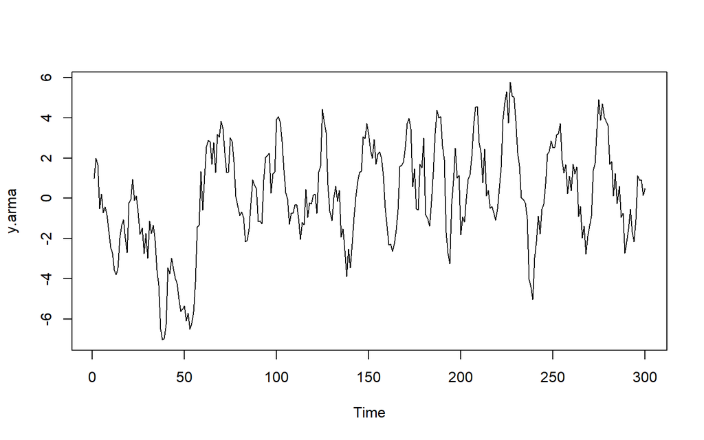

```r
ts.plot(y.arma)
```

### plot ACF

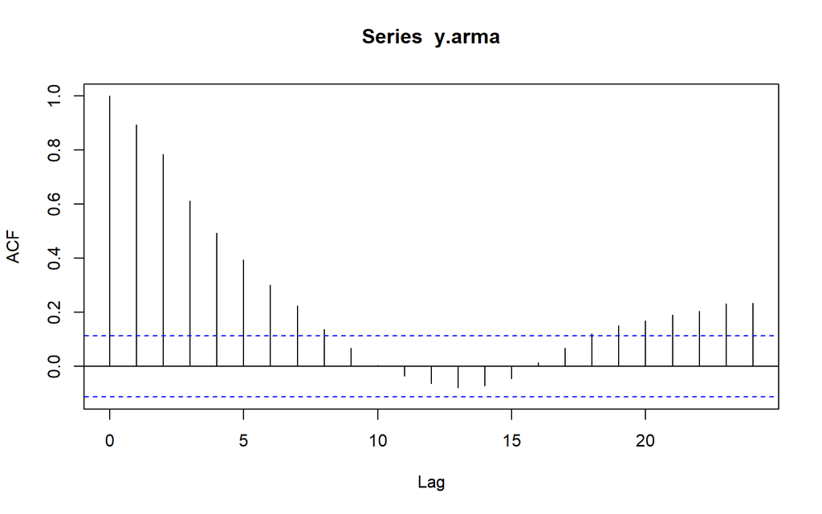

```r
acf(y.arma)
```

Berdasarkan plot ACF tersebut, terlihat bahwa model ARMA(2,2) hasil simulasi memiliki plot ACF yang tails off

### plot PACF

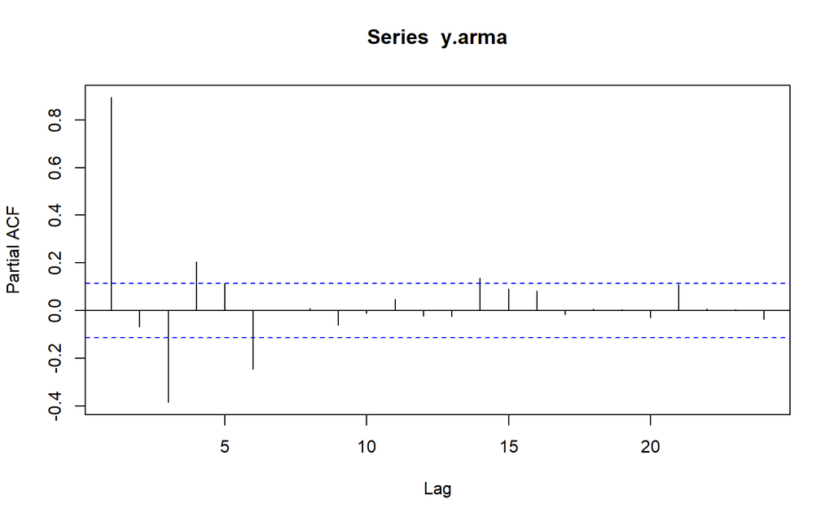

```r
pacf(y.arma)
```

Berdasarkan plot PACF tersebut, terlihat bahwa model ARMA(2,2) hasil simulasi memiliki plot PACF yang tails off, sesuai dengan teori

### plot EACF

```r
TSA::eacf(y.arma)
```

```
## AR/MA
##   0 1 2 3 4 5 6 7 8 9 10 11 12 13
## 0 x x x x x x x x o o o  o  o  o
## 1 o x o o o o x o o o o  o  o  o
## 2 x x o o o o x o o o o  o  o  o
## 3 x x o x o o x o o o o  o  o  o
## 4 x x x x o o x o o o o  o  o  o
## 5 x x x x x x x o o o o  o  o  o
## 6 o o x o x x o o o o o  o  o  o
## 7 x o x o x x o x o o o  o  o  o
```

Berdasarkan pola segitiga nol pada plot EACF, terlihat bahwa segitiga nol berada pada ordo AR(2) dan ordo MA(2)

## Buat scatterplot antara 𝑌𝑡 dengan 𝑌𝑡−1, 𝑌𝑡 dengan 𝑌𝑡−2 serta 𝑌𝑡 dengan 𝑌𝑡−3

### 𝑌𝑡 dengan 𝑌𝑡−1

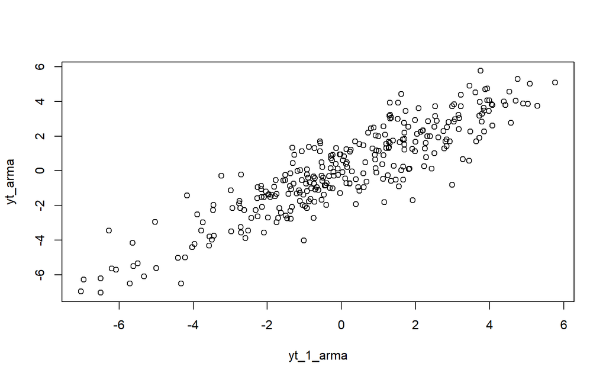

```r
#Yt
yt_arma <- y.arma[-1]
yt_1_arma <- y.arma[-300]

plot(y=yt_arma,x=yt_1_arma)
```

### 𝑌𝑡 dengan 𝑌𝑡−2

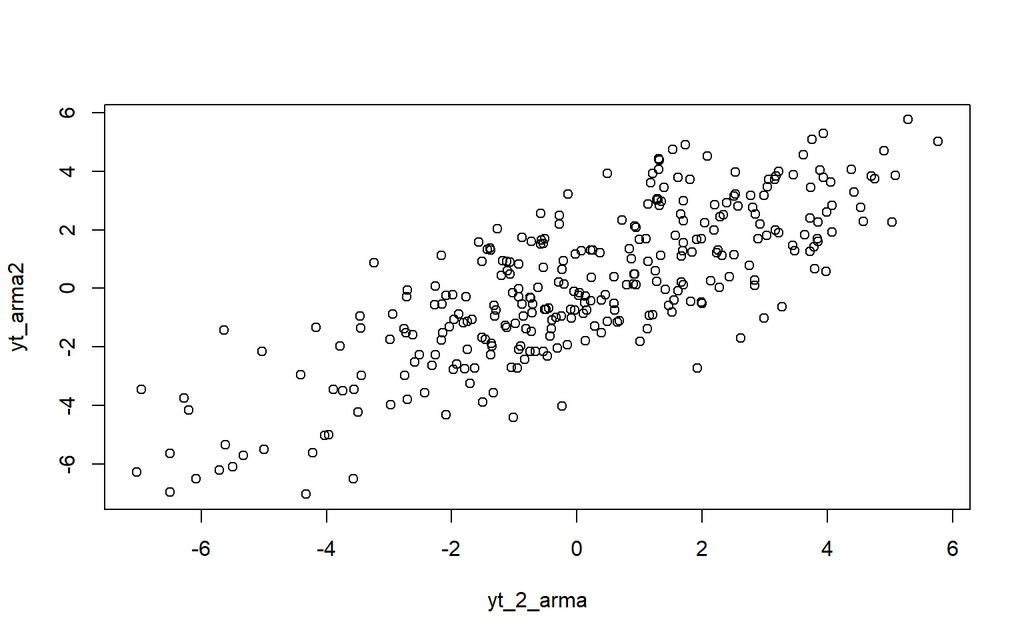

```r
yt_arma2 <- y.arma[-c(1,2)]
yt_2_arma <- y.arma[-c(299,300)]

plot(y=yt_arma2, x=yt_2_arma)
```

### 𝑌𝑡 dengan 𝑌𝑡−3

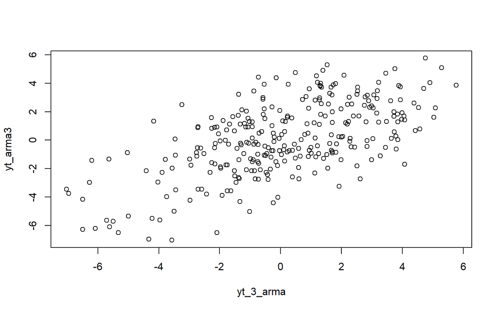

```r
yt_arma3 <- y.arma[-c(1,2,3)]
yt_3_arma <- y.arma[-c(298,299,300)]

plot(y=yt_arma3, x=yt_3_arma)
```

## Hitung autokorelasi masing masing baik dari data bangkitan maupun secara teoriti

### 𝑌𝑡 dengan 𝑌𝑡−1

```r
cor(yt_arma,yt_1_arma)
```

```
## [1] 0.8943281
```

### 𝑌𝑡 dengan 𝑌𝑡−2

```r
cor(yt_arma2, yt_2_arma)
```

```
## [1] 0.7865019
```

### 𝑌𝑡 dengan 𝑌𝑡−3

```r
cor(yt_arma3, yt_3_arma)
```

```
## [1] 0.6135111
```

### perhitungan teoritis

$$\psi_1=\phi_1+\theta_1
=0.5+0.4
=0.9$$

$$\psi_2=\phi_1\psi_1+\phi_2+\theta_2
=(0.5)(0.9)+0.2+0.6
=1.25$$

$$\gamma_1
=
0.5\gamma_0+0.2\gamma_1
+0.4+0.6(0.9)$$

$$\gamma_1
=
0.5\gamma_0+0.2\gamma_1+0.94$$

$$\gamma_2
=
0.5\gamma_1+0.2\gamma_0+0.6$$

$$\gamma_0
=
0.5\gamma_1+0.2\gamma_2
+1+0.4(0.9)+0.6(1.25)$$

$$\gamma_0
=
0.5\gamma_1+0.2\gamma_2+2.11$$

$$\gamma_0=5.017094,\qquad
\gamma_1=4.310684,\qquad
\gamma_2=3.758761$$

$$\rho_1
=
\frac{\gamma_1}{\gamma_0}
=
\frac{4.310684}{5.017094}
=
0.859199$$

$$\rho_2
=
\frac{\gamma_2}{\gamma_0}
=
\frac{3.758761}{5.017094}
=
0.749191$$

karena $3>q=2$,

$$\gamma_3
=
\phi_1\gamma_2+\phi_2\gamma_1$$

$$\gamma_3
=
(0.5)(3.758761)+(0.2)(4.310684)
=
2.741518$$

$$\rho_3
=
\frac{\gamma_3}{\gamma_0}
=
\frac{2.741518}{5.017094}
=
0.546435$$

$$\boxed{
\rho_1=0.859199,\quad
\rho_2=0.749191,\quad
\rho_3=0.546435
}$$
```